# midterm

Philip Belov

October 13, 2015

```r
library(dplyr)
library(ggplot2)
library(readr)
```

```r
users = read_csv("/principal/materials/minor/midterm/users.csv")
orders = read_csv("/principal/materials/minor/midterm/orders.csv")
inventory = read_csv("/principal/materials/minor/midterm/inventory.csv")
```

# TASK 1

## 1

### *Table.* People who use the shop more frequently

```r
orders_frequency = left_join(users, orders, by="user_id") %>%
  group_by(user_id) %>%
  dplyr::summarize(count = n()) %>%
  arrange(desc(count)) %>%
  top_n(10, count)
orders_frequency =
  left_join(orders_frequency, users, by="user_id") %>%
  select(user_id, first_name, last_name, count)
pander::pandoc.table(orders_frequency)
```

| user_id | first_name | last_name | count |
| --- | --- | --- | --- |
| 118 | Louise | Garrett | 400 |
| 170 | Antonio | Turner | 338 |
| 40 | Tammy | Barnes | 332 |
| 26 | Gary | Sullivan | 314 |
| 175 | Jean | Jordan | 234 |
| 17 | Ruth | Hughes | 227 |
| 114 | Stephen | Evans | 204 |
| 94 | George | Weaver | 171 |
| 97 | Jennifer | Reyes | 145 |
| 21 | Joyce | Edwards | 144 |

## 2

### *Table.* 3 most expensive cars

```r
cars = filter(inventory, category=="Cars") %>%
  select(item, price)%>%
  arrange(desc(price)) %>%
  top_n(3, price)
pander::pandoc.table(cars)
```

| item | price |
| --- | --- |
| Mazda 2 sport | 15515 |
| Hyundai Accent | 15455 |
| Toyota Yaris | 15240 |

## 3

```r
phones = filter(inventory, category=="Phones") %>% select(-category)
phones_ext =
  left_join(phones, orders, by="inventory_id") %>%
  select(inventory_id, item, quantity)
phones_ext = group_by(phones_ext, inventory_id) #%>%
phones_ext = dplyr::summarize(phones_ext, sum_quantity = sum(quantity))
phones_ext = arrange(phones_ext, desc(sum_quantity))
phones_ext =
  left_join(phones_ext, phones, by="inventory_id") %>%
  select(inventory_id, item, sum_quantity)
```

### *Graph.* The most popular phones

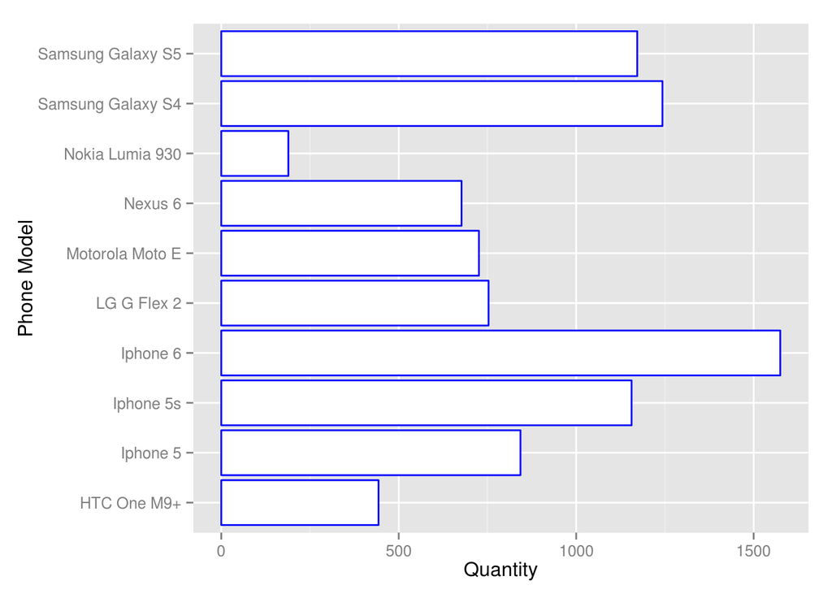

```r
ggplot() +
  geom_bar(data=phones_ext, aes(x=item, y=sum_quantity), stat="identity", fill="white", color="blue") +
  xlab("Phone Model") +
  ylab("Quantity") +
  coord_flip()
```

*From this graph you can see that the most popular phone manufacturing company is **Apple**. The second place is held by **Samsung**.*

# TASK 2

## 1

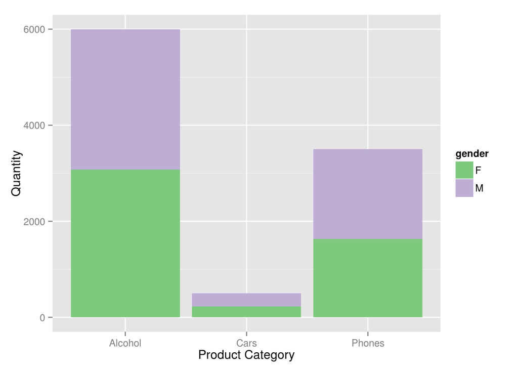

```r
faceless = select(users, user_id, gender, job_title)
faceless = left_join(faceless, orders, by="user_id")
faceless = left_join(faceless, inventory, by="inventory_id")
faceless = select(faceless, user_id, gender, job_title, inventory_id, quantity, category, item, price)
ggplot() +
  geom_bar(data=faceless, aes(x=category, fill=gender)) +
  xlab("Product Category") +
  ylab("Quantity") +
  scale_fill_brewer(palette="Accent")
```

*From the graph above we can see that **Alcohol** is the most popular product category amongst people. We can conclude that each gender has nearly equal preferences in terms of product category. The two tables below prove that statement.*

```r
male_preferences = faceless %>% filter(gender=="M") %>% group_by(category) %>% dplyr::summarize(count = n()) %>% arrange(desc(count))
female_preferences = faceless %>% filter(gender=="F") %>% group_by(category) %>% dplyr::summarize(count = n()) %>% arrange(desc(count))
```

### *Table.* Male Preferences

```r
pander::pandoc.table(male_preferences)
```

| category | count |
| --- | --- |
| Alcohol | 2924 |
| Phones | 1870 |
| Cars | 273 |

### *Table.* Female Preferences

```r
pander::pandoc.table(female_preferences)
```

| category | count |
| --- | --- |
| Alcohol | 3076 |
| Phones | 1630 |
| Cars | 227 |

## 2

**Note:** faceless df is used later in task 3. Initially, I misunderstood the task 2.2 that’s why it’s not so rationally solved.

```r
faceless = mutate(faceless, sum_price=price*quantity)
expenditures = group_by(faceless, user_id) %>% dplyr::summarize(group_sum_price = sum(sum_price))
moneyspenders = left_join(expenditures, users, by="user_id") %>% arrange(desc(group_sum_price)) %>%
  select(user_id, first_name, last_name, job_title, group_sum_price)
```

### *Table.* Top money spenders

```r
pander::pandoc.table(top_n(moneyspenders, 5, group_sum_price))
```

| user_id | first_name | last_name | job_title | group_sum_price |
| --- | --- | --- | --- | --- |
| 170 | Antonio | Turner | Management | 716997 |
| 118 | Louise | Garrett | Management | 627325 |
| 26 | Gary | Sullivan | Management | 492087 |
| 40 | Tammy | Barnes | Management | 411473 |
| 17 | Ruth | Hughes | Management | 374006 |

*The people who spends most money are **managers**. The top moneyspender is Antonio Turner!*

# TASK 3

## 1 & 2

```r
tbl_categories = table(faceless$category, faceless$job_title)
chisq.test(tbl_categories)
```

```
##
##  Pearson's Chi-squared test
##
## data:  tbl_categories
## X-squared = 104.93, df = 8, p-value < 2.2e-16
```

```r
chisq <- chisq.test(tbl_categories)
```

```r
pander::pandoc.table(chisq$residuals, split.cells = c(4,7,7,7,7,7))
```

[output not shown]

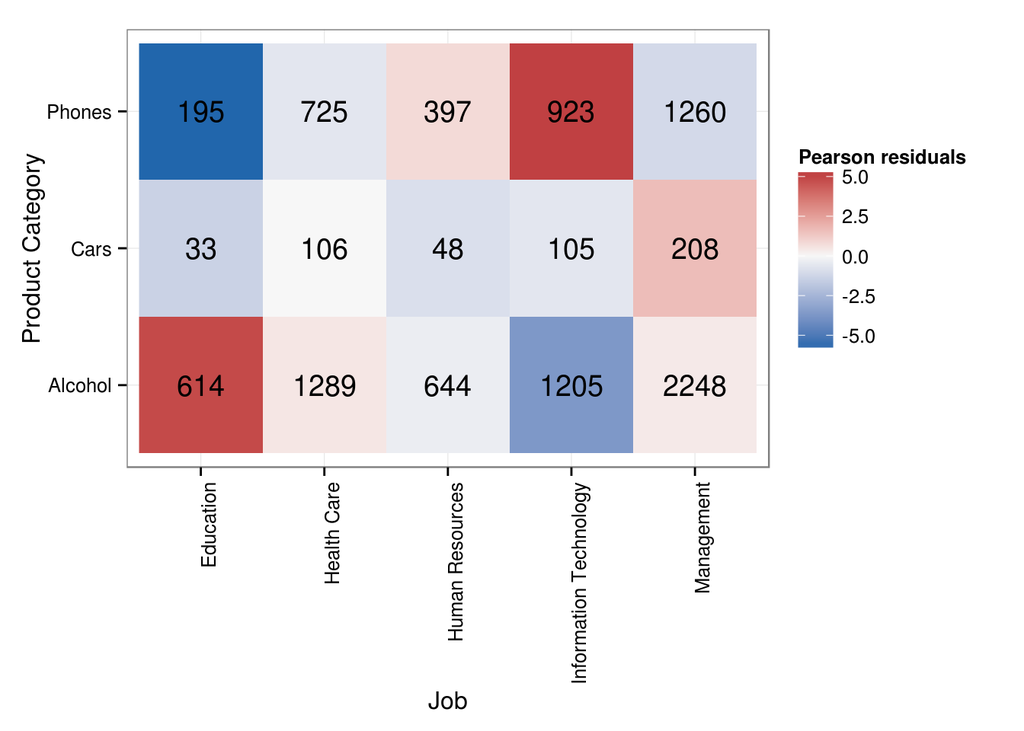

```r
df_resid = as.data.frame(chisq$residuals)
df_count = as.data.frame(tbl_categories)

ggplot() +
  geom_raster(data = df_resid, aes(Var2, Var1, fill = Freq), hjust = 0.5, vjust = 0.5) +
  scale_fill_gradient2("Pearson residuals", low = "#2166ac", mid = "#f7f7f7", high = "#b2182b", midpoint = 0) +
  geom_text(data = df_count, aes(Var2, Var1, label = Freq)) +
  xlab("Job") +
  ylab("Product Category") +
  theme_bw() +
  theme(axis.text.x = element_text(angle = 90, hjust = 1))
```

*From this graph we can see that workers in the education have a tendency towards alcoholism. IT workers, however, prefer to buy phones.*

*This is my initial solution of task 2.2.*

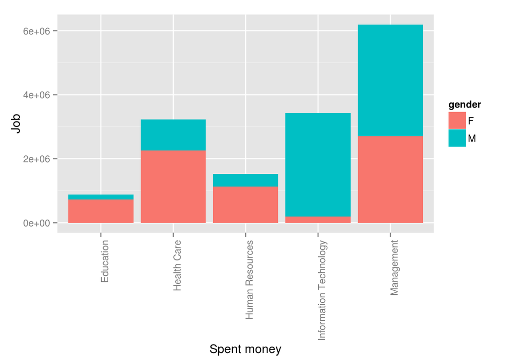

```r
faceless_ext =
  left_join(faceless, expenditures, by="user_id") %>%
  select(user_id, gender, job_title, group_sum_price) %>%
  subset(!duplicated(user_id)) %>%
  group_by(gender) %>%
  arrange(desc(group_sum_price))

ggplot() +
  geom_bar(data=faceless_ext, aes(x=job_title, y=group_sum_price, fill=gender), stat="identity") +
  xlab("Spent money") +
  ylab("Job") +
  theme(axis.text.x = element_text(angle = 90, hjust = 1))
```

*The biggest amount of money is spent by **managers** then come the **IT guys**, the third place is taken by workers in **health care** sphere. Also from the graph we can see that male managers and IT guys are spending more money than females in the appropriate job categories. In the other 3 categories women are dominating in the amount of money spent.*